# Read Counts

2023-04-03

1. Reading in featureCounts results

```r
# Read in the data
folder <- "/Users/johnmorris/Desktop/Comp_Bio_MS_Weill_Cornell/Spring_2023/ANGSD/Project_Download/final_project_scripts/gene_counts_NAFLD" # download count table! ## reading in featureCounts output
readcounts <- read.table(t(folder), header = TRUE)
#read_counts_transform <- t(readcounts)
```

NOTE: One issue I had when running the feature_counts function, was the extremely low % of Successfully assigned alignments, which showed around 2% for each value. This can be found my looking at ’‘’cat /home/nam4021/project/project_org/slurm-10633599.out’’’. I don’t believe this is a normal amount.

```r
# Change the rownames to easily readable condition/replicate names
original_names <- names(readcounts)

names(readcounts) <- c(names(readcounts)[1:6],
  "HIGH_1", "HIGH_2", "HIGH_3", "HIGH_4", "LOW_1",
  "LOW_2", "LOW_3", "LOW_4")

str(readcounts)
```

```
## 'data.frame':    3897 obs. of  14 variables:
##  $ Geneid: chr  "DDX11L1" "WASH7P" "MIR6859-1" "MIR1302-2HG" ...
##  $ Chr   : chr  "NC_000001.11;NC_000001.11;NC_000001.11" "NC_000001.11;NC_000001.11;NC_000001.11;NC_000001.11;NC_000001.11;NC_000001.11;NC_000001.11;NC_000001.11;NC_0000"| __truncated__ "NC_000001.11;NC_000001.11;NC_000001.11" "NC_000001.11;NC_000001.11;NC_000001.11" ...
##  $ Start : chr  "11874;12613;13221" "14362;14970;15796;16607;16858;17233;17606;17915;18268;24738;29321" "17369;17369;17409" "29774;30976;34168" ...
##  $ End   : chr  "12227;12721;14409" "14829;15038;15947;16765;17055;17368;17742;18061;18366;24891;29370" "17436;17391;17431" "30667;31093;35418" ...
##  $ Strand: chr  "+;+;+" "-;-;-;-;-;-;-;-;-;-;-" "-;-;-" "+;+;+" ...
##  $ Length: int  1652 1769 68 2263 138 1130 2618 5590 4266 2584 ...
##  $ HIGH_1: int  0 28 1 0 0 0 0 1 3 1 ...
##  $ HIGH_2: int  0 19 0 1 0 0 0 1 1 7 ...
##  $ HIGH_3: int  0 19 2 0 0 0 0 2 6 2 ...
##  $ HIGH_4: int  0 16 0 0 0 0 1 4 2 0 ...
##  $ LOW_1 : int  0 25 1 0 0 0 0 15 2 4 ...
##  $ LOW_2 : int  0 17 0 0 0 0 0 2 8 2 ...
##  $ LOW_3 : int  0 19 0 0 0 0 1 3 1 2 ...
##  $ LOW_4 : int  0 14 5 0 0 0 0 1 7 2 ...
```

2. DESeq2 object set up and organization

```r
#BiocManager::install("DESeq2")
library(DESeq2)
row.names(readcounts) <- make.names(readcounts$Geneid)

# Eliminate unnecessary rows

readcounts <- readcounts[ , -c(1:6)]

head(readcounts)
```

```
##             HIGH_1 HIGH_2 HIGH_3 HIGH_4 LOW_1 LOW_2 LOW_3 LOW_4
## DDX11L1          0      0      0      0     0     0     0     0
## WASH7P          28     19     19     16    25    17    19    14
## MIR6859.1        1      0      2      0     1     0     0     5
## MIR1302.2HG      0      1      0      0     0     0     0     0
## MIR1302.2        0      0      0      0     0     0     0     0
## FAM138A          0      0      0      0     0     0     0     0
```

```r
## Create sample_info
sample_info <- data.frame(condition = gsub("[0-9]+", "", names(readcounts)),
                         row.names = names(readcounts) )
sample_info
```

```
##        condition
## HIGH_1     HIGH_
## HIGH_2     HIGH_
## HIGH_3     HIGH_
## HIGH_4     HIGH_
## LOW_1       LOW_
## LOW_2       LOW_
## LOW_3       LOW_
## LOW_4       LOW_
```

```r
str(sample_info)
```

```
## 'data.frame':    8 obs. of  1 variable:
##  $ condition: chr  "HIGH_" "HIGH_" "HIGH_" "HIGH_" ...
```

```r
# Create the DESeq object
DESeq.ds <- DESeqDataSetFromMatrix(countData = as.matrix(readcounts),
                                   colData = sample_info,
                                   design = ~ condition)
DESeq.ds
```

```
## class: DESeqDataSet
## dim: 3897 8
## metadata(1): version
## assays(1): counts
## rownames(3897): DDX11L1 WASH7P ... LOC105372879 IL24
## rowData names(0):
## colnames(8): HIGH_1 HIGH_2 ... LOW_3 LOW_4
## colData names(1): condition
```

```r
head(counts(DESeq.ds))
```

```
##             HIGH_1 HIGH_2 HIGH_3 HIGH_4 LOW_1 LOW_2 LOW_3 LOW_4
## DDX11L1          0      0      0      0     0     0     0     0
## WASH7P          28     19     19     16    25    17    19    14
## MIR6859.1        1      0      2      0     1     0     0     5
## MIR1302.2HG      0      1      0      0     0     0     0     0
## MIR1302.2        0      0      0      0     0     0     0     0
## FAM138A          0      0      0      0     0     0     0     0
```

```r
# Check the sums of the reads for each condition
colSums(counts(DESeq.ds))
```

```
##  HIGH_1  HIGH_2  HIGH_3  HIGH_4   LOW_1   LOW_2   LOW_3   LOW_4
## 1830069 1471328 1397591 1561721 1264122 1301993 1343897 1491274
```

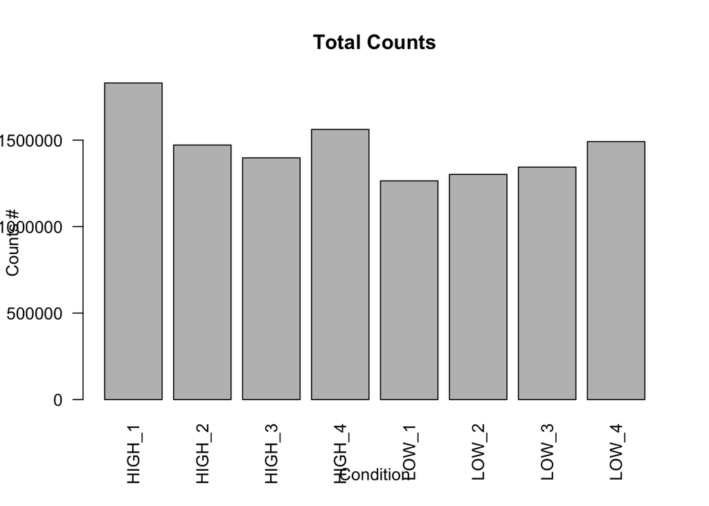

```r
barplot(colSums(counts(DESeq.ds)), main = "Total Counts", ylab = "Counts #", xlab = "Condition", las = 2)
```

```r
# Original dimensions with empty genes
dim(DESeq.ds)
```

```
## [1] 3897    8
```

```r
library(magrittr)
# Eliminate rows with empty genes
keep_genes <- rowSums(counts(DESeq.ds)) > 0
DESeq.ds <- DESeq.ds[ keep_genes, ]
dim(DESeq.ds)
```

```
## [1] 3160    8
```

```r
counts(DESeq.ds) %>% str
```

```
##  int [1:3160, 1:8] 28 1 0 0 1 3 1 4 2 16 ...
##  - attr(*, "dimnames")=List of 2
##   ..$ : chr [1:3160] "WASH7P" "MIR6859.1" "MIR1302.2HG" "OR4F5" ...
##   ..$ : chr [1:8] "HIGH_1" "HIGH_2" "HIGH_3" "HIGH_4" ...
```

```r
assay(DESeq.ds) %>% str
```

```
##  int [1:3160, 1:8] 28 1 0 0 1 3 1 4 2 16 ...
##  - attr(*, "dimnames")=List of 2
##   ..$ : chr [1:3160] "WASH7P" "MIR6859.1" "MIR1302.2HG" "OR4F5" ...
##   ..$ : chr [1:8] "HIGH_1" "HIGH_2" "HIGH_3" "HIGH_4" ...
```

3. Normalizing for sequence depth and RNA composition differences

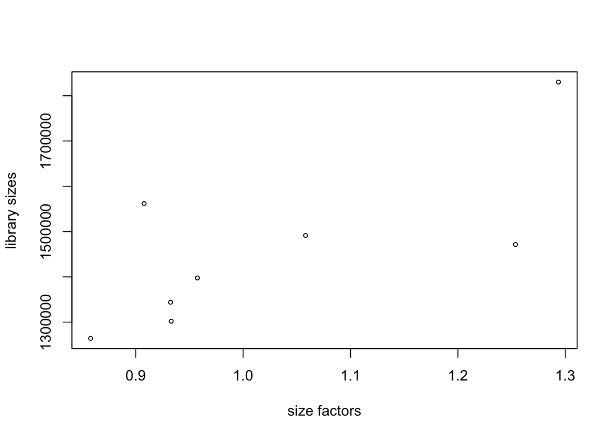

```r
 DESeq.ds <- estimateSizeFactors(DESeq.ds) # calculate SFs, add them to object
plot( sizeFactors(DESeq.ds), colSums(counts(DESeq.ds)), # assess them
      ylab = "library sizes", xlab = "size factors", cex = .6 )
```

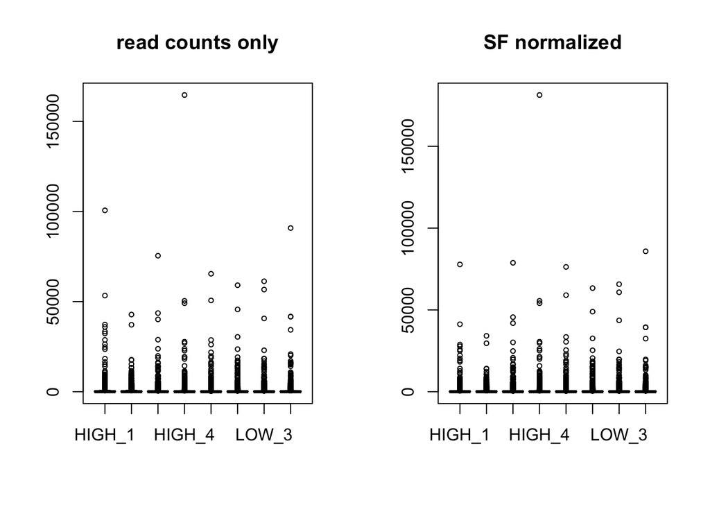

```r
## setting up the plotting layout
par(mfrow=c(1,2))
## extracting normalized counts
counts.sf_normalized <- counts(DESeq.ds, normalized=TRUE)
## adding the boxplots
boxplot(counts(DESeq.ds), main = "read counts only", cex = .6)
boxplot(counts.sf_normalized, main = "SF normalized", cex = .6)
```

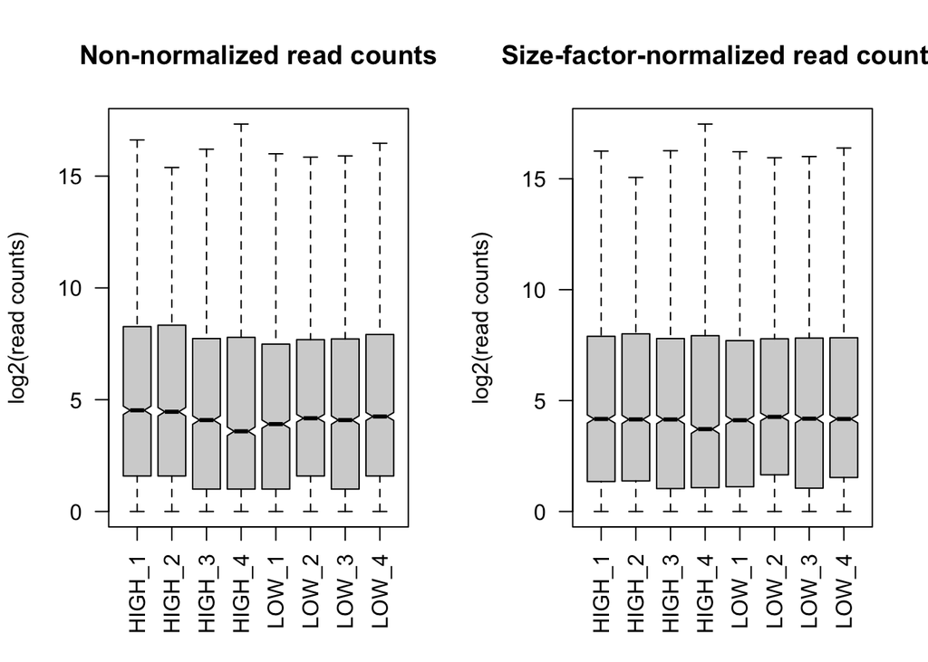

```r
# Transform the normalized read counts to bring them onto similar scales

par(mfrow=c(1,2)) # to plot the two box plots next to each other
## bp of non-normalized
boxplot(log2(counts(DESeq.ds) +1), notch=TRUE,
        main = "Non-normalized read counts",
        ylab ="log2(read counts)", cex = .6, las = 2)
## bp of size-factor normalized values
boxplot(log2(counts(DESeq.ds, normalized=TRUE) +1), notch=TRUE,
        main = "Size-factor-normalized read counts",
        ylab ="log2(read counts)", cex = .6, las = 2)
```

1. Understanding more properties of read count data

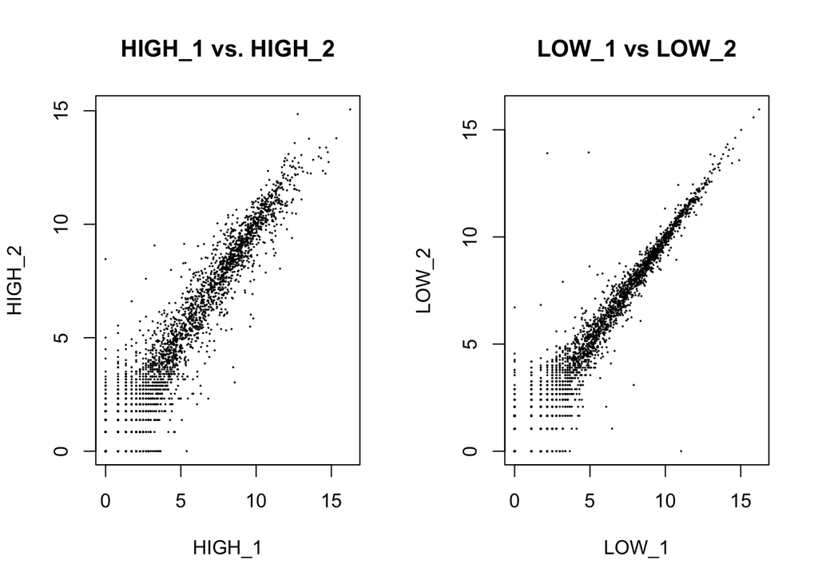

```r
## Make a scatterplot of log normalized counts against each other to see how well the values correlate within a condition per sample and gene. Here we focus on two samples.

## non-normalized read counts plus pseudocount
log.counts <- log2(counts(DESeq.ds, normalized = FALSE) + 1)
## instead of creating a new object, we could assign the values to a distinct matrix ## within the DESeq.ds object
assay(DESeq.ds, "log.counts") <- log2(counts(DESeq.ds, normalized = FALSE) + 1)
## normalized read counts
assay(DESeq.ds, "log.norm.counts") <- log2(counts(DESeq.ds, normalized=TRUE) + 1)
par(mfrow=c(1,2))
DESeq.ds[, c("HIGH_1","HIGH_2")] %>%
  assay(.,  "log.norm.counts") %>%
  plot(., cex=.1, main = "HIGH_1 vs. HIGH_2")
DESeq.ds[, c("LOW_1","LOW_2")] %>%
  assay(.,  "log.norm.counts") %>%
  plot(., cex=.1, main = "LOW_1 vs LOW_2")
```

As shown in the practical, the points should primarily only fan out at the lower levels, since they should correlate less well when they are low. However, for the HIGH condition, they don’t correlate very well when they are high. For the LOW condition, they seem to correlate better.

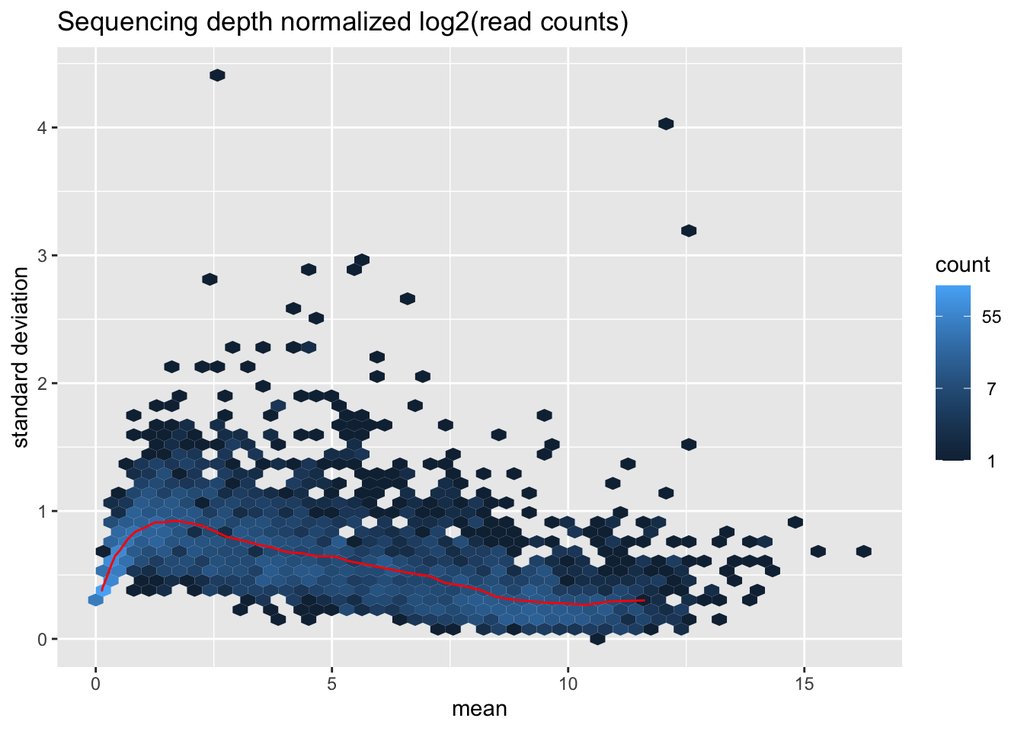

```r
#BiocManager::install("vsn")
library(vsn)
library(ggplot2)
## generate the base meanSdPlot using sequencing depth normalized log2(read counts) ## set up plotting frame
par(mfrow=c(1,1))
## generate the plot
msd_plot <- vsn::meanSdPlot(assay(DESeq.ds, "log.norm.counts"), ranks=FALSE, # show the data on the original scale
plot = FALSE)
## since vsn::meanSdPlot generates a ggplot2 object, this can be manipulated in the usual ways
msd_plot$gg +
  ggtitle("Sequencing depth normalized log2(read counts)") +
  ylab("standard deviation")
```

This depicts that there is a variance-mean dependence with low read counts, or else the red line would be horizontal. The data shows signs of heteroskedasticity!

2. Reducing the dependence of the variance on the mean

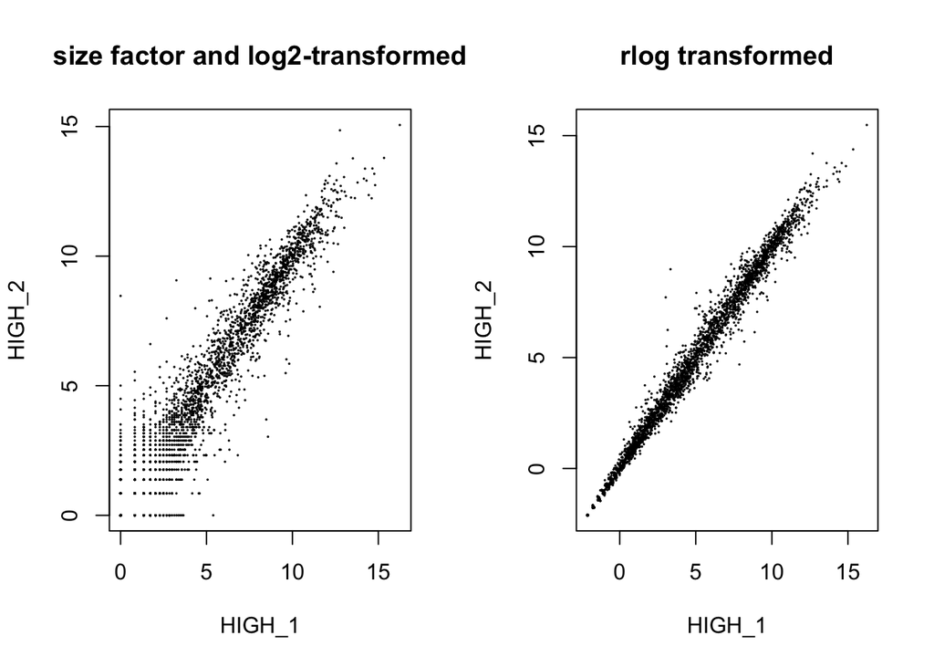

```r
## this actually generates a different type of object!
DESeq.rlog <- rlog(DESeq.ds, blind = TRUE)
## set blind = FALSE if the conditions are expected to introduce ## strong differences in a large proportion of the genes
## (blind means blind to the experimental design)
par(mfrow=c(1,2))
plot(assay(DESeq.ds, "log.norm.counts")[,1:2], cex=.1,
     main = "size factor and log2-transformed")
## the rlog-transformed counts are stored in the "assay" accessor
plot(assay(DESeq.rlog)[,1:2],
     cex=.1, main = "rlog transformed",
     xlab = colnames(assay(DESeq.rlog[,1])),
     ylab = colnames(assay(DESeq.rlog[,2])) )
```

The rlog transformed plot seems to show lesser variance across all of the read counts.

```r
rlog.norm.counts <- assay(DESeq.rlog)
```

Now, we have expression values that have been adjusted for: • differences in sequencing depth; • differences in RNA composition; • heteroskedasticity; • large dynamic range.

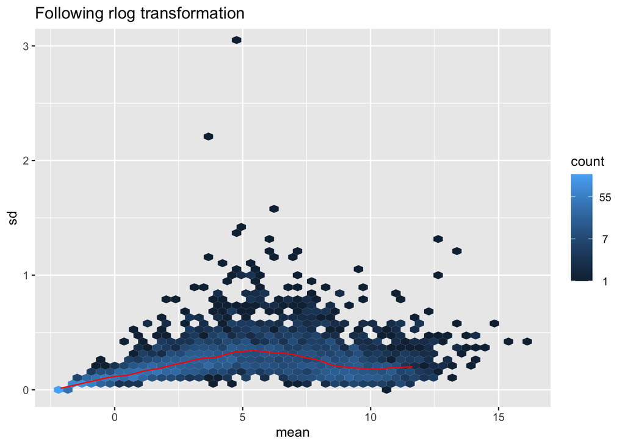

```r
## rlog-transformed read counts
msd_plot <- vsn::meanSdPlot(assay(DESeq.rlog), ranks=FALSE, plot = FALSE)
msd_plot$gg + ggtitle("Following rlog transformation") +
  coord_cartesian(ylim = c(0,3))
```

Looks a lot better!